# Milestone Report Capstone Project

## 1) Introduction

This report brings the results of the exploratory data analysis that was performed on a corpus called HC Corpora (www.corpora.heliohost.org) and also what will be the strategy for the prediction algorithm and the data product application.

## 2) Exploratory Data Analysis

The data consists of files from twitter, news and blogs on four languages (English, Deutch, Finnish and Russian). It is possible to check, for each language, what is the word occurence of different number of words together. This is the base of the prediction algorithm that will be explained on Section 3. As an example, if approximately 10% of the En_US twitter file is chosen, an histogram of the words occurences for the 1-gram sequence is shown on the figure below:

```r
# remove variables and set working directory
rm(list=ls())
# Text mining related libraries
library(tm)
library(tau)
```

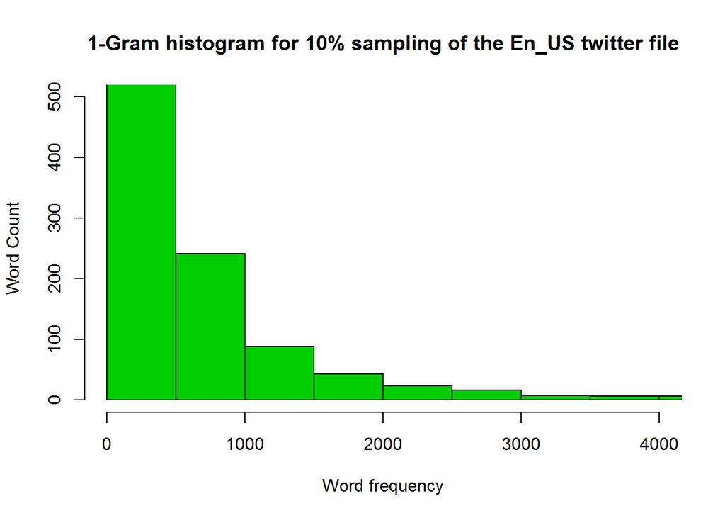

```r
# read approximately 10% of the lines of the twitter En_US file
t <- readLines("./data/en_US/twitter/en_US.twitter.txt",n=200000)
# English stop words
words <- readLines(system.file("stopwords", "english.dat", package = "tm"))
# remove stop words
t <- remove_stopwords(t, words, lines = T)
# text count for 1-gram
t <- textcnt(t, method = "string", n = 1)
t <- data.frame(freq=unclass(t))
hist(t[,1], main = paste("1-Gram histogram for 10% sampling of the En_US twitter file"), xlab = "Word frequency", ylab = "Word Count",ylim = c(0,500),xlim = c(0,4000),col = 3)
```

For this sample, the total number of words, excluding th stop words, is of approximately 80.000 and the maximum frequency of 12.000. This is shown below:

```r
dim(t)
```

```
## [1] 79084     1
```

```r
head(t[order(t[,1],decreasing=T),])
```

```
## [1] 12552 10724 10418  9339  9125  8489
```

Also a cleanning process to exclude “incorrect” words like the ones shown below have to be performed:

```r
head(t)
```

```
##                              freq
## a                             436
## aa                             25
## aaa                             3
## aaaaaaaaaahhhhhhhhhhhhhhhhhh    1
## aaaaaaaaaayyyyyyeeeeeeeee       1
## aaaaaaahhhh                     1
```

The same analysis can be made with different number of word sets. The example below shows a 2-gram for the same file sample.

```r
# read approximately 10% of the lines of the twitter En_US file
t <- readLines("./data/en_US/twitter/en_US.twitter.txt",n=200000)
# English stop words
words <- readLines(system.file("stopwords", "english.dat", package = "tm"))
# remove stop words
t <- remove_stopwords(t, words, lines = T)
# text count for 1-gram
t <- textcnt(t, method = "string", n = 2)
t <- data.frame(freq=unclass(t))
dim(t)
```

```
## [1] 981355      1
```

```r
head(t[order(t[,1],decreasing=T),])
```

```
## [1] 1434 1004  764  690  681  627
```

In this example 981355 sets of two words were found with a maximum occurence of 1434 for the most frequent.

## 3) Prediction Algorithm

The prediction algorithm will be based on the n-gram model, which is a probabilistic language model for predicting the next item in such a sequence in the form of a (n-1)-order Markov Model. As an example, for the same file that was shown on section 2, if the word “case” is typed by the user, if the 2-gram model is used, the next recommended word would be “study”, according to the frequency of this word set.

```r
t2 <- subset(t, grepl("case",rownames(t)))
t2[,2] <- rownames(t2)
t2 <- t2[order(t2[,1],decreasing = T),]
head(t2)
```

```
##               freq            V2
## just case       26     just case
## casey anthony   12 casey anthony
## case study       8    case study
## case studies     7  case studies
## case scenario    5 case scenario
## well case        5     well case
```

## 4) Data Product

The planned data product will provide words filling recommendations based on the words that were already typed by the user. Basically it will consist of a text box and a panel where a given number of recommended words will be shown.

## 5) Conclusion

This reports described briefly the exploratory data analysis that was performed on a language corpus. It also described the strategy for the prediction algorithm and the data product that will be developed to address the problem.

## 6) References

- www.corpora.heliohost.org
- https://en.wikipedia.org/wiki/N-gram